```r
options(OutDec = ".")

# Establecer semilla aleatoria
set.seed(sample(1:10000, 1))

# Aleatorización del contexto
familias <- c("Ramírez", "González", "Martínez", "García", "López", "Rodríguez",
              "Hernández", "Pérez", "Sánchez", "Torres")
familia <- sample(familias, 1)

# Plan actual de minutos (aleatorizar entre 200-300)
plan_minutos <- sample(c(200, 220, 250, 280, 300), 1)

# Generar datos de consumo para 7 meses
meses_nombres <- c("Jul.", "Ago.", "Sep.", "Oct.", "Nov.", "Dic.", "Ene.")

# Generar consumo aleatorio asegurando que enero tenga consumo adicional
consumo_base <- round(plan_minutos * runif(7, 0.6, 1.5))
# Asegurar que al menos uno supere el plan (enero)
consumo_base[7] <- plan_minutos + sample(80:150, 1)

consumo_meses <- consumo_base

# Calcular el consumo adicional de enero
consumo_enero <- consumo_meses[7]
tiempo_adicional_minutos <- consumo_enero - plan_minutos

# Convertir a horas y minutos
horas_adicional <- floor(tiempo_adicional_minutos / 60)
minutos_adicional <- tiempo_adicional_minutos %% 60

# Datos de la tabla del estado de cuenta
# Aleatorizar valores
saldo_anterior <- sample(c(45000, 48000, 49610), 1)
gracias_pago <- sample(c(-48000, -49610, -47500), 1) * -1
cargos_mes <- sample(c(34000, 35416.83, 36000), 1)
iva <- round(cargos_mes * 0.19)
subtotal <- cargos_mes + iva
credito_ajuste <- sample(c(-5, -5.53, -6), 1) * -1
total_pagar <- subtotal - credito_ajuste

# Cargos del mes detallados
plan_local <- sample(c(19000, 20086.21, 21000), 1)
consumo_adicional_costo <- sample(c(13000, 14065.92, 15000), 1)
llamada_espera <- sample(c(1200, 1264.70, 1300), 1)
total_cargos_mes <- cargos_mes

# Generar opciones de respuesta
# Opción correcta
opcion_correcta <- paste0(horas_adicional, " hora", ifelse(horas_adicional > 1, "s", ""),
                          " y ", minutos_adicional, " minutos.")

# Generar distractores
distractor1_min <- tiempo_adicional_minutos + sample(30:50, 1)
dist1_h <- floor(distractor1_min / 60)
dist1_m <- distractor1_min %% 60
distractor1 <- paste0(dist1_h, " hora", ifelse(dist1_h > 1, "s", ""),
                      " y ", dist1_m, " minutos.")

distractor2_min <- tiempo_adicional_minutos - sample(20:40, 1)
dist2_h <- floor(distractor2_min / 60)
dist2_m <- distractor2_min %% 60
distractor2 <- paste0(dist2_h, " hora", ifelse(dist2_h > 1, "s", ""),
                      " y ", dist2_m, " minutos.")

distractor3_min <- tiempo_adicional_minutos + sample(200:250, 1)
dist3_h <- floor(distractor3_min / 60)
dist3_m <- distractor3_min %% 60
distractor3 <- paste0(dist3_h, " hora", ifelse(dist3_h > 1, "s", ""),
                      " y ", dist3_m, " minutos.")

# Crear lista de opciones y mezclar
opciones <- c(opcion_correcta, distractor1, distractor2, distractor3)
opciones_mezcladas <- sample(opciones)

# Identificar posición correcta
indice_correcto <- which(opciones_mezcladas == opcion_correcta)

# Vector de solución
solucion <- rep(0, 4)
solucion[indice_correcto] <- 1

# Tests de validación
test_that("El consumo de enero supera el plan", {
  expect_true(consumo_enero > plan_minutos)
})
```

Test passed 😸

```r
test_that("El cálculo de tiempo adicional es correcto", {
  expect_equal(tiempo_adicional_minutos, consumo_enero - plan_minutos)
})
```

Test passed 🥳

```r
test_that("La conversión a horas y minutos es correcta", {
  expect_equal(horas_adicional * 60 + minutos_adicional, tiempo_adicional_minutos)
})
```

Test passed 🎊

```r
options(OutDec = ".")

# Código Python para generar el gráfico de barras
codigo_python <- sprintf("
import matplotlib
matplotlib.use('Agg')
import matplotlib.pyplot as plt
import numpy as np

# Configuración
plt.style.use('default')
plt.rcParams['font.size'] = 10
plt.rcParams['axes.linewidth'] = 1.2

# Datos
meses = %s
consumo = %s
plan_actual = %d

# Crear figura
fig, ax = plt.subplots(figsize=(6, 4))

# Colores para las barras
colores = ['#4682B4'] * len(meses)
colores[-1] = '#E74C3C'  # Enero en rojo por ser el mes con consumo adicional

# Crear gráfico de barras
barras = ax.bar(meses, consumo, color=colores, edgecolor='black', linewidth=0.8)

# Añadir valores sobre las barras
for i, (barra, valor) in enumerate(zip(barras, consumo)):
    altura = barra.get_height()
    ax.text(barra.get_x() + barra.get_width()/2., altura,
            f'{int(valor)}',
            ha='center', va='bottom', fontweight='bold', fontsize=9)

# Línea del plan actual
ax.axhline(y=plan_actual, color='green', linestyle='--', linewidth=2,
           label=f'Su plan local actual es de {plan_actual} minutos')

# Configuración del gráfico
ax.set_xlabel('Últimos consumos de voz', fontweight='bold')
ax.set_ylabel('Minutos consumidos', fontweight='bold')
ax.set_title('Diagrama de barras de los últimos\\nconsumos de voz', fontsize=11, fontweight='bold')
ax.legend(loc='upper left', fontsize=8)
ax.grid(axis='y', alpha=0.3, linestyle='--')
ax.set_ylim(0, max(consumo) * 1.15)

plt.tight_layout()

# Guardar
plt.savefig('grafico_consumo.png', dpi=150, bbox_inches='tight', facecolor='white')
plt.savefig('grafico_consumo.pdf', dpi=150, bbox_inches='tight', facecolor='white')
plt.close()
",
paste0("['", paste(meses_nombres, collapse="', '"), "']"),
paste0("[", paste(consumo_meses, collapse=", "), "]"),
plan_minutos)

# Ejecutar Python
py_run_string(codigo_python)
```

```r
options(OutDec = ".")

# Función para formatear números con separador de miles
format_currency <- function(x) {
  format(x, big.mark = ",", decimal.mark = ".", nsmall = 2, scientific = FALSE)
}

# Crear tabla con TikZ para el estado de cuenta
tabla_estado <- c(
  "\\begin{tikzpicture}",
  "\\node[inner sep=0pt] {",
  "  \\begin{tabular}{|p{4.5cm}|r|}",
  "    \\hline",
  "    \\rowcolor{cyan!15}",
  "    \\multicolumn{2}{|c|}{\\textbf{Estado de cuenta mes de enero}} \\\\",
  "    \\hline",
  paste0("    Saldo anterior & \\$", format_currency(saldo_anterior), " \\\\"),
  "    \\hline",
  paste0("    Gracias por su pago & -\\$", format_currency(gracias_pago), " \\\\"),
  "    \\hline",
  "    \\rowcolor{orange!20}",
  "    \\textbf{Saldo} & \\textbf{\\$0} \\\\",
  "    \\hline",
  paste0("    Cargos del mes & \\$", format_currency(cargos_mes), " \\\\"),
  "    \\hline",
  paste0("    IVA & \\$", format_currency(iva), " \\\\"),
  "    \\hline",
  "    \\rowcolor{orange!20}",
  paste0("    \\textbf{Subtotal} & \\textbf{\\$", format_currency(subtotal), "} \\\\"),
  "    \\hline",
  paste0("    Crédito por ajuste a la decena & -\\$", format_currency(credito_ajuste), " \\\\"),
  "    \\hline",
  "    \\rowcolor{orange!30}",
  paste0("    \\textbf{Total a pagar} & \\textbf{\\$", format_currency(total_pagar), "} \\\\"),
  "    \\hline",
  "    \\hline",
  "    \\rowcolor{cyan!15}",
  "    \\multicolumn{2}{|c|}{\\textbf{Cargos del mes}} \\\\",
  "    \\hline",
  paste0("    Plan local & \\$", format_currency(plan_local), " \\\\"),
  "    \\hline",
  paste0("    Consumo adicional & \\$", format_currency(consumo_adicional_costo), " \\\\"),
  "    \\hline",
  paste0("    Llamada en espera & \\$", format_currency(llamada_espera), " \\\\"),
  "    \\hline",
  "    \\rowcolor{orange!20}",
  paste0("    \\textbf{Total cargos del mes} & \\textbf{\\$", format_currency(total_cargos_mes), "} \\\\"),
  "    \\hline",
  "  \\end{tabular}",
  "};",
  "\\end{tikzpicture}"
)
```

# Question

La gráfica y la tabla muestran parte de la información que recibe la familia Martínez en su factura telefónica del mes de enero.

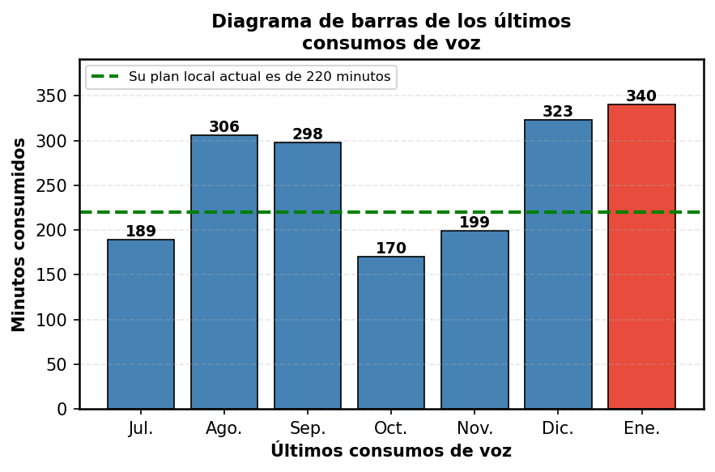

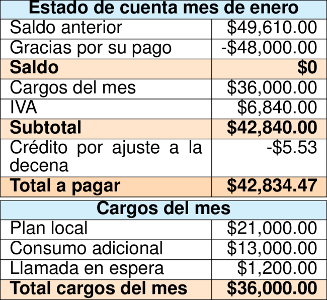

El tiempo adicional consumido por la familia Martínez en enero fue:

## Answerlist

- 2 horas y 50 minutos.
- 2 horas y 0 minutos.
- 5 horas y 42 minutos.
- 1 hora y 28 minutos.

# Solution

Para resolver este problema, debemos:

1. **Identificar el plan actual**: Según la gráfica, el plan local actual es de **220 minutos**.
2. **Identificar el consumo de enero**: En el gráfico de barras, el consumo de enero (la última barra) es de **340 minutos**.
3. **Calcular el tiempo adicional**:
   $$\text{Tiempo adicional} = \text{Consumo enero} -
   \text{Plan actual}$$
   $$\text{Tiempo
   adicional} = 340 - 220 = 120 \text{ minutos}$$
4. **Convertir a horas y minutos**:
   - Horas: $\lfloor 120 \div 60 \rfloor = 2$ hora(s)
   - Minutos restantes: $120 \mod 60 = 0$ minutos

**Respuesta correcta**: 2 horas y 0 minutos.

## Answerlist

- Falso
- Verdadero
- Falso
- Falso

# Meta-information

exname: consumo_telefonico_adicional extype: schoice exsolution: 0100 exshuffle: TRUE exsection: Estadística/Interpretación de Gráficos/Nivel 2 extags: ICFES, Interpretación, Numérico-Variacional, Estadística, Aplicado exdificultad: 2 excompetencia: Interpretación y Representación excomponente: Numérico-Variacional expensamiento: Pensamiento Numérico excontenido: Estadística (Genérico) exeje: Aplicado/Contextualizado